# Third-Party Intervention in Intrastate War

December 4, 2015

## Outline

1. Motivation & Relevance
2. Research Question
3. Data
4. Model
5. Analysis
6. Results

## 1. Motivation & Relevance

[figure not shown]

## 1. Motivation & Relevance

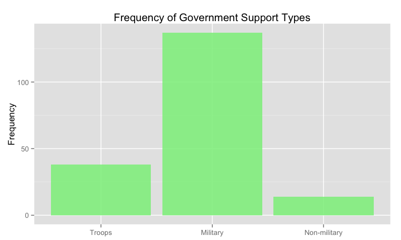

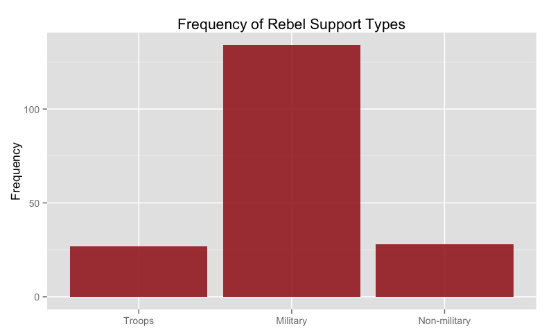

## 2. Research Question

**How do different forms of third-party intervention affect the outcome of a conflict?**

Assumptions:

- **H1:** The more fungible the support to rebels, the less likely is a rebel victory
- **H2:** Troops and military support to governments will increase the probability of a government military victory only when opposition military strength approaches that of the state.

## 3. Data

- Two Datasets: 1. Non-state Actor dataset & 2. Replication dataset
- Cover years from 1975 to 2009
- Conflict Unit = Conflict Dyad
- 169 different conflict dyads
- Limitations: Covert weapons transfers and data on lethal aid

## 4. Model

**Dependent Variable**

- Conflict Outcome
- 1. Rebel Military Victory, 2. Government Military Victory, 3. Negotiated Settlement, or 4. Low Intensity

**Independent Variable**

- Type of support to either government or rebels
- 1. Troops, 2. Military, or 3. Non-military

## 4. Model

**Control Variables**

- Fighting Capacity
- GDP
- Coup
- Duration of Conflict
- Legal Political Wing
- Secessionist

## 5. Analysis

[figure not shown]

## 5. Analysis

[figure not shown]

## 6. Results

**Significant results:**

1. Any type of government support will decrease the probabiity for a negotiated settlement
2. Rebel support: Only military support will decrease the probability for a government victory
3. If the rebels have a legal political wing a negotiated settlement becomes more likely
4. A secession by the rebels decreases the probability for a negotiated settlement and increases the likelihood for a rebel victory

## Feedback

[figure not shown]